# B Bryan meta-analysis code review

K N Thompson, September 2022

In this code review, K N Thompson will replicate all STATA code to conduct the meta-analysis for the publication by B Bryan “Bryan, B. T., Andrews, G., Thompson, K. N., Qualter, P., Matthews, T., Arseneault, L. (under review), Loneliness in the workplace: a mixed method systematic review and meta-analysis, Psychological Bulletin”.

The stata code used in the paper takes the following steps:

- Read in data
- Recode variables
- Conduct Fisher’s transformation
- Prepare data for meta analysis
- Run meta-analysis
- Create forest plot

# Read in the data

```r
dat.raw <- read_csv("KT_meta_analysis_data.csv")
colnames(dat.raw)
```

[1] “Authors” “Year” “N”  
[4] “r” “Occupational group” “Loneliness measure” [7] “Correlate measure” “Correlate”

# Recode the variables

STATA code:

```
* Recode variables
rename var1 authors
label var authors "Study authors"
rename var2 year
label var year "Publication year"
rename var3 n
label var n "Sample size"
rename var4 r
label var r "Correlation co-efficient"
rename var5 corr_scale
label var corr_scale "Correlate measure"
```

Below I have renamed the variables to the labels that were set in the STATA code.

**“co-efficient” doesn’t need a hyphen.**

R code:

```r
dat <- dat.raw %>%
  dplyr::select(
         `Study Authors` = Authors,
         `Publication year` = Year,
         `Sample size` = N,
         `Correlation coefficient` = r,
         `Occupational group`,
         `Loneliness measure`,
         `Correlate measure`,
         Correlate
  )

colnames(dat)
```

[1] “Study Authors” “Publication year”  
[3] “Sample size” “Correlation coefficient” [5] “Occupational group” “Loneliness measure”  
[7] “Correlate measure” “Correlate”

# Fisher’s transformation

STATA code:

```
* Fisher's z transformation
gen z = .5 * ln((1 + r) / (1 - r))
label var z "Fishers z transformation r"
gen sez = sqrt(1/(n - 3))
label var sez "SE of z"
```

R code:

```r
dat <- dat %>%
  mutate(
    `Fishers z transformation r` =
      FisherZ(`Correlation coefficient`)
  )

describe(dat$`Fishers z transformation r`)
```

|  | vars | n | mean | sd | median | trimmed | mad | min | max | range | skew | kurtosis | se |
| --- | --- | --- | --- | --- | --- | --- | --- | --- | --- | --- | --- | --- | --- |
| X1 | 1 | 27 | -0.159001 | 0.3917714 | -0.2768638 | -0.1803609 | 0.2766823 | -0.8851702 | 0.829114 | 1.714284 | 0.7029996 | -0.1504217 | 0.07539644 |

```r
dat <- dat %>%
  mutate(
    `SE of z` =
      sqrt(1/(`Sample size` - 3))
  )

describe(dat$`Fishers z transformation r`)
```

|  | vars | n | mean | sd | median | trimmed | mad | min | max | range | skew | kurtosis | se |
| --- | --- | --- | --- | --- | --- | --- | --- | --- | --- | --- | --- | --- | --- |
| X1 | 1 | 27 | -0.159001 | 0.3917714 | -0.2768638 | -0.1803609 | 0.2766823 | -0.8851702 | 0.829114 | 1.714284 | 0.7029996 | -0.1504217 | 0.07539644 |

# Prepare data for meta analysis

STATA code:

```
* Meta set data
meta set z sez, studylabel(authors)
```

I also added in the Correlate and Correlate measure here.

R code:

```r
dat.meta <- dat %>%
  dplyr::select(
         `Study Authors`,
         `Fishers z transformation r`,
         `SE of z`,
         Correlate,
         `Correlate measure`
  )

colnames(dat.meta)
```

[1] “Study Authors” “Fishers z transformation r” [3] “SE of z” “Correlate”  
[5] “Correlate measure”

```r
dat.meta <- dat.meta %>%
  mutate(
    Correlate.factor =
      as_factor(Correlate)
  )
is.factor(dat.meta$Correlate.factor)
```

[1] TRUE

# Run meta-analysis

STATA code:

```
meta summarize, random(reml) transform(corr) subgroup(corr_scale)
```

R translation:

- Restricted Maximum-Likelihood (reml) as the estimator
- subgroup analysis use the correlate measure? Here we will run a subgroup meta-analysis using Correlate, as well as running separate meta-analyses while stratifying by Correlate.

## All studies included together

```r
# all studies
meta_analysis_re_total <- rma(yi = `Fishers z transformation r`,    # effect sizes or outcomes - this is z
                              sei = `SE of z`,                      # standard errors
                              method = "REML",                      # estimator - random effects specified through REML
                              data = dat.meta                       # dataset
)

# subgroup analysis
meta_analysis_re_sub  <- rma(yi = `Fishers z transformation r`,    # effect sizes or outcomes - this is z
                              sei = `SE of z`,                      # standard errors
                              method = "REML",                      # estimator - random effects specified through REML
                              mods = ~ Correlate.factor-1,          # create subgroup analysis using the correlates
                              data = dat.meta                       # dataset
)
```

## Seperate meta analyses for each correlate

```r
dat.meta.burnout <- dat.meta %>% filter(Correlate == "Burnout")
dat.meta.job.perf <- dat.meta %>% filter(Correlate == "Job performance")
dat.meta.job.sat <- dat.meta %>% filter(Correlate == "Job satisfaction")
dat.meta.man.rel <- dat.meta %>% filter(Correlate == "Manager relationship (LMX)")
```

```r
# Burnout
meta_analysis_re_burnout <- rma(yi = `Fishers z transformation r`,  # effect sizes or outcomes - this is z
                              sei = `SE of z`,                      # standard errors
                              method = "REML",                      # estimator - random effects specified through REML
                              data = dat.meta.burnout               # dataset
)

# Job performance
meta_analysis_re_job.perf <- rma(yi = `Fishers z transformation r`, # effect sizes or outcomes - this is z
                              sei = `SE of z`,                      # standard errors
                              method = "REML",                      # estimator - random effects specified through REML
                              data = dat.meta.job.perf              # dataset
)

# Job satisfaction
meta_analysis_re_job.sat <- rma(yi = `Fishers z transformation r`,  # effect sizes or outcomes - this is z
                              sei = `SE of z`,                      # standard errors
                              method = "REML",                      # estimator - random effects specified through REML
                              data = dat.meta.job.sat               # dataset
)

# Manager relationship
meta_analysis_re_man.rel <- rma(yi = `Fishers z transformation r`,  # effect sizes or outcomes - this is z
                              sei = `SE of z`,                      # standard errors
                              method = "REML",                      # estimator - random effects specified through REML
                              data = dat.meta.man.rel               # dataset
)
```

# Create results table

```r
table <- function(data, model){
  table <- data.frame(matrix(nrow = 1,ncol = 9))
  colnames(table) <- c("Model", "Theta estimate", "Confidence interval lower", "Confidence interval upper", "Standard error", "Q", "tau2", "%I2", "H2")
  table <- table %>%
    mutate(`Theta estimate` = round(data$b, 3)) %>%
    mutate(`Confidence interval lower` = round(data$ci.lb, 3)) %>%
    mutate(`Confidence interval upper` = round(data$ci.ub, 3)) %>%
    mutate(`Standard error` = round(data$se, 3)) %>%
    mutate(Q = round(data$QE, 3)) %>%
    mutate(tau2 = round(data$tau2, 3)) %>%
    mutate(`%I2` = round(data$I2, 3)) %>%
    mutate(`H2` = round(data$H2, 3)) %>%
    mutate(Model = c(model))
  return(table)
}
```

```r
table.burnout <- table(data = meta_analysis_re_burnout, model = "Burnout")
table.job.perf <- table(data = meta_analysis_re_job.perf, model = "Job performance")
table.job.sat <- table(data = meta_analysis_re_job.sat, model = "Job satisfaction")
table.man.rel <- table(data = meta_analysis_re_man.rel, model = "Manager relationship (LMX)")

table.all <- rbind(table.burnout, table.job.perf, table.job.sat, table.man.rel)
table.all
```

| Model | Theta estimate | Confidence interval lower | Confidence interval upper | Standard error | Q | tau2 | %I2 | H2 |
| --- | --- | --- | --- | --- | --- | --- | --- | --- |
| Burnout | 0.408 | 0.251 | 0.566 | 0.080 | 83.593 | 0.042 | 93.826 | 16.197 |
| Job performance | -0.371 | -0.530 | -0.212 | 0.081 | 100.177 | 0.055 | 94.358 | 17.725 |
| Job satisfaction | -0.359 | -0.477 | -0.241 | 0.060 | 39.374 | 0.019 | 89.800 | 9.804 |
| Manager relationship (LMX) | -0.325 | -0.404 | -0.246 | 0.040 | 17.445 | 0.006 | 77.346 | 4.414 |

# Forest plots

## Overall

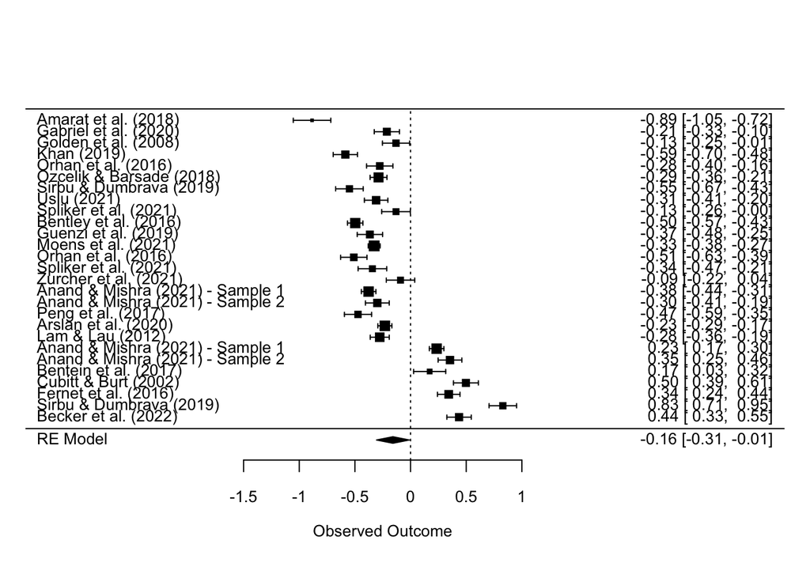

```r
forest(meta_analysis_re_total, slab = dat.meta$`Study Authors`)
```

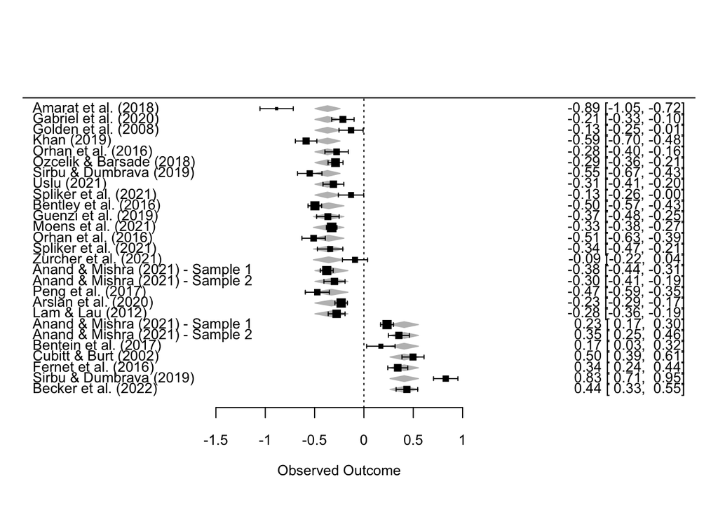

```r
forest(meta_analysis_re_sub, slab = dat.meta$`Study Authors`)
```

## Subgrouped

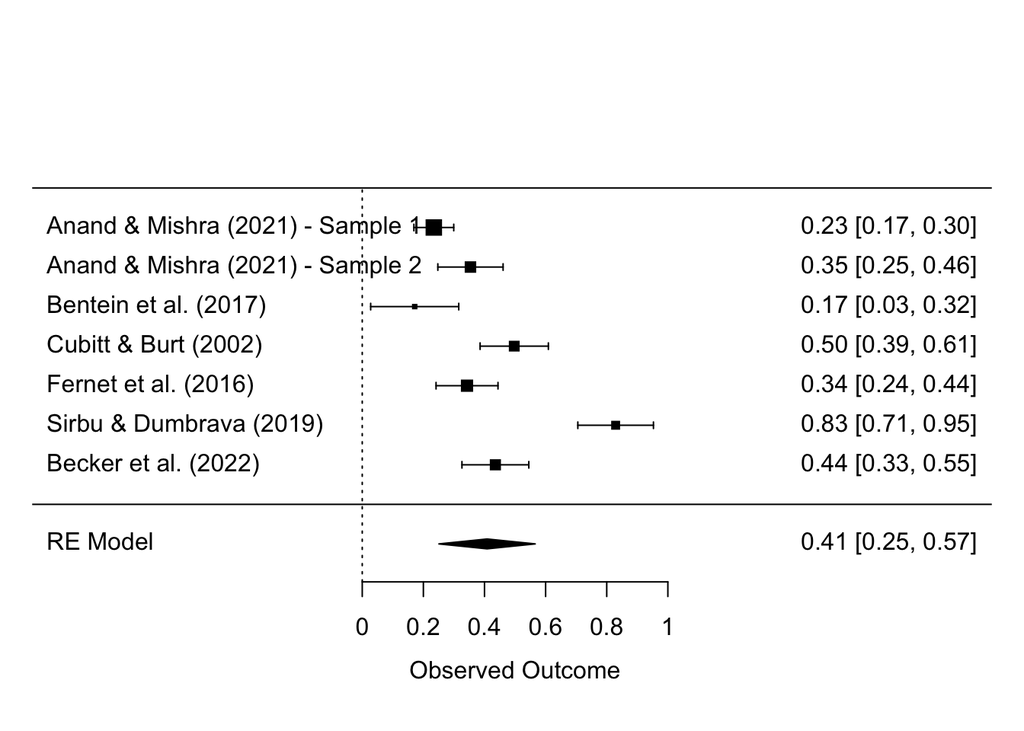

```r
# Burnout
forest(meta_analysis_re_burnout, slab = dat.meta.burnout$`Study Authors`)
```

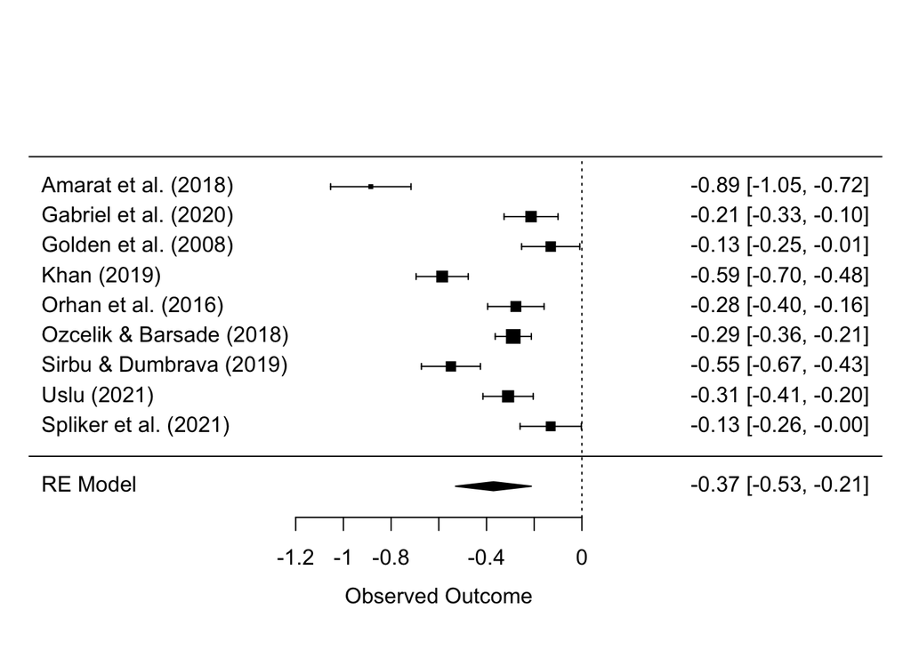

```r
# Job performance
forest(meta_analysis_re_job.perf, slab = dat.meta.job.perf$`Study Authors`)
```

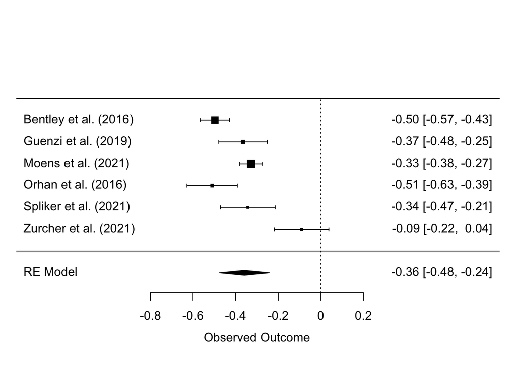

```r
# Job satisfaction
forest(meta_analysis_re_job.sat, slab = dat.meta.job.sat$`Study Authors`)
```

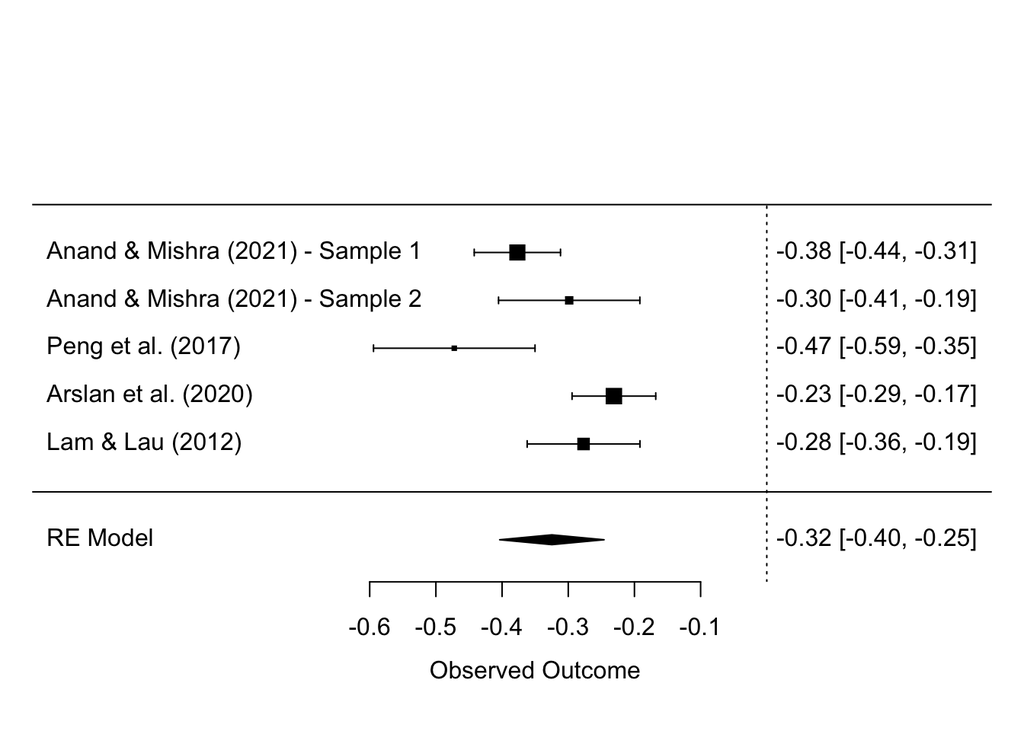

```r
# Manager relationship
forest(meta_analysis_re_man.rel, slab = dat.meta.man.rel$`Study Authors`)
```